# Explore OHI Global Data & Data Gaps for United Kingdom

## Objectives

To explore the OHI Global data for United Kingdom, focusing on where data are estimated (gapfilled) instead of available in global data sets for United Kingdom.

## Gapfilling in United Kingdom

Let’s look a bit deeper to see numerically the percent gapfilling by goal to help us prioritize which goals we want to explore more deeply. We can pull directly from the data from the [Frazier et al. 2015](http://journals.plos.org/plosone/article?id=10.1371/journal.pone.0160377) publication.

It’s interesting to compare the percent gapfilling by goal to the scores by goal. Let’s look at this figure and discuss what we see.

### Figure: % Gapfilled vs. Status Scores

There may be a few places where there are overlaps because goals have the exact same scores.

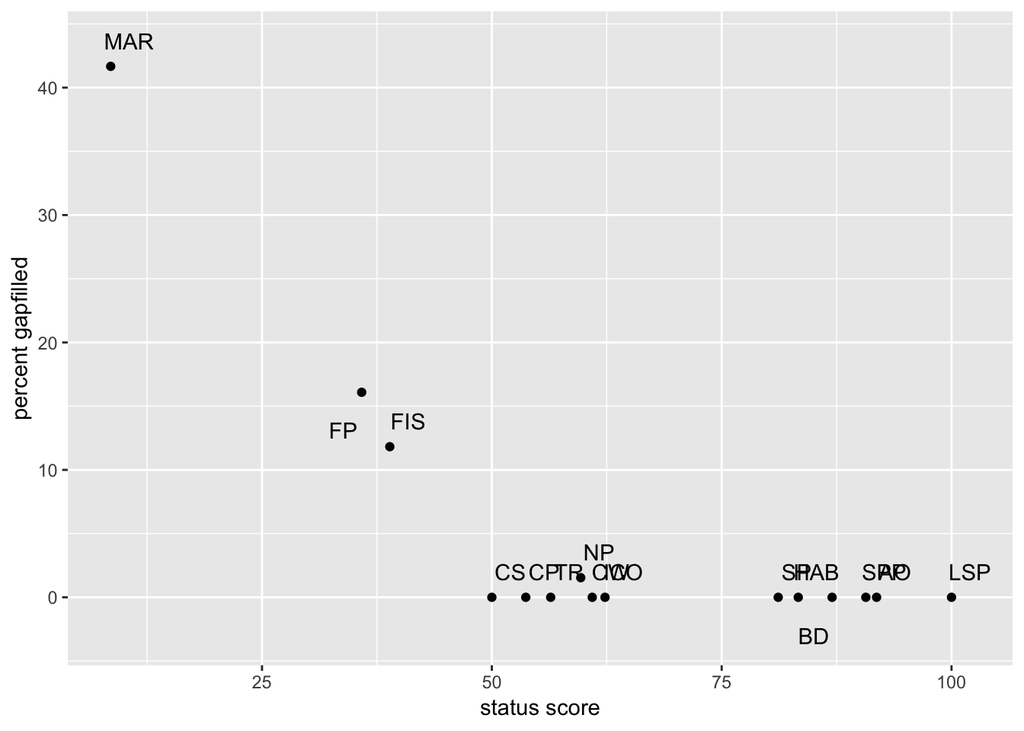

## Gapfilling Observations

Let’s brainstorm together: let’s list overall observations and observations by goal. Then we will prioritize which to dive deeply into and look at the underlying data with the time we have.

### Overall

**Observations:**

### Food Provision (FP)

**Observations**:

### Tourism and Recreation (TR)

### Species-based goals (ICO, SPP)

### Livelihoods and Economies (LE, LIV, ECO)

**Observations**:

- The LE goal is not on the figure. We didn’t include them in our gapfilling analyses because our models rely on old data (pre-2012).

Now, where should we start? What order should we discuss these?

## Data discussion: deep dive

Let’s look into the data behind some of these goals.

We will use several resources for each goal, all linked from [ohi-science.org/ohi-global](http://ohi-science.org/ohi-global%5D):

- ohi-science.org/ohi-global/goals
- [ohi-science.org/ohi-global/layers_table](http://ohi-science.org/ohi-global/layers_table.html)
- [Global supplemental information](https://rawgit.com/OHI-Science/ohi-global/draft/global_supplement/Supplement.html)

## [Food Provision: Fisheries](http://ohi-science.org/ohi-global/goals.html#food_provision:_fisheries)

**Questions:**

- Which species are included in the FIS calculation? Where do the data come from?

#### Global Data

Global data are from the [**Sea Around Us Project**](http://www.seaaroundus.org), which does spatial allocation modeling of FAO catch. Many species do not have formal stock assessments, but they do have tons of catch through time. The criteria we use for our fisheries model is data that has:

- **catch by species**: only what is fished within United Kingdom’s EEZ
- **years**: at least 10 years of data (preferably 20)

We can look at these data in several ways. Let’s start by looking on SAUP’s website at an interactive visualization of fish caught in United Kingdom’s exclusive economic zone (EEZ). Here’s how:

1. Navigate to seaaroundus.org
2. Click “Tools & Data”
3. Search “United Kingdom”

We can also look at the mapped locations of fishing effort by United Kingdom (remember that OHI only includes catch caught withing United Kingdom’s EEZ.

1. Click “Mapped Data”

Let’s look through the species listed and see if there are any included that don’t represent United Kingdom’s fisheries within the EEZ.

#### Mean catch

The mean catch layer ([fis_meancatch](https://github.com/OHI-Science/esw/blob/master/global_explore/data/fis_meancatch_lookup.csv)) is in some ways a historic list because it includes species that may not be caught any more (i.e. was fished in the past and stopped for some reason). It is calculated as the average (mean) of each species’ catch through time, so if it was a big catch in the past but now is 0, it will still average (it keeps all species in the dataset).

It will be more useful for us to look at the raw catch values, and see if any of them don’t seem right. Below the scientific name is listed, with the common name (if known).

|  | stock_name | common |
| --- | --- | --- |
| 1 | Marine_fishes_not_identified |  |
| 2 | Miscellaneous_marine_crustaceans |  |
| 3 | Miscellaneous_aquatic_invertebrates |  |
| 4 | Marine_finfishes_not_identified |  |
| 5 | Marine_groundfishes_not_identified |  |
| 6 | Marine_pelagic_fishes_not_identified |  |
| 7 | Mollusca |  |
| 8 | Elasmobranchii |  |
| 9 | Chondrichthyes |  |
| 10 | Cephalopoda |  |

[output cut: 352 more lines]

There are 362 species in the [fis_meancatch](https://github.com/OHI-Science/esw/blob/master/global_explore/data/fis_meancatch_lookup.csv) layer for United Kingdom.

#### Raw catch data

To understand mean catch, dive into catch by species.

Let’s do two things. First, look through the list of species to see if any of them should be removed.

There are 366 unique species.

Do we want to look at the timeseries for any species? For example:

|  | year | taxon_scientific_name | taxon_common_name | tons | stock_id |
| --- | --- | --- | --- | --- | --- |

#### B/Bmsy

These are the species stocks that we have data for [fis_b_bmsy](https://github.com/OHI-Science/esw/blob/master/global_explore/data/fis_b_bmsy_lookup.csv):

|  | stock_name | common |
| --- | --- | --- |
| 1 | Glyptocephalus_cynoglossus | Witch flounder |
| 2 | Lepidorhombus_whiffiagonis | Megrim |
| 3 | Micromesistius_poutassou | Blue whiting |
| 4 | Molva_molva | Ling |
| 5 | Pollachius_pollachius | Pollack |
| 6 | Anguilla_anguilla | European eel |
| 7 | Chelidonichthys_cuculus | Red gurnard |
| 8 | Brosme_brosme | Tusk |
| 9 | Capros_aper | Boarfish |
| 10 | Cyclopterus_lumpus | Lumpfish |

[output cut: 77 more lines]

There are only 87 species in the [fis_b_bmsy](https://github.com/OHI-Science/esw/blob/master/global_explore/data/fis_b_bmsy_lookup.csv) layer for United Kingdom.

Let’s look at these too. Are there any species that don’t seem right?

#### Discussion

- Are there any species that don’t seem right and we should remove, for meancatch or B/Bmsy?
- There are many categories that we only have information at the genus or family levels. Do you have information for species level?

## [Food Provision: Mariculture](http://ohi-science.org/ohi-global/goals.html#food_provision:_mariculture)

**Questions:**

- How do we interpret the MAR score?

### Global Data

#### Tonnes of Harvest

Let’s look at the list of species that are represented in the MAR model as tonnes of harvest: (the [mar_harvest_tonnes](https://github.com/OHI-Science/esw/blob/master/eez/layers/mar_harvest_tonnes.csv) layer).

|  | taxa |
| --- | --- |
| 1 | Atlantic cod |
| 2 | Atlantic halibut |
| 3 | Atlantic salmon |
| 4 | Blue mussel |
| 5 | Common edible cockle |
| 6 | Cupped oysters nei |
| 7 | European flat oyster |
| 8 | European seabass |
| 9 | Great Atlantic scallop |
| 10 | Grooved carpet shell |

[output cut: 7 more lines]

Let’s have a peek at the data:

|  | taxa_code | year_min | year_max | total_tonnes | mean_tonnes |
| --- | --- | --- | --- | --- | --- |
| 1 | Atlantic cod_655 | 2001 | 2016 | 3568.7 | 223.04375 |
| 2 | Atlantic halibut_656 | 1999 | 2016 | 2233.1 | 124.061111111111 |
| 3 | Atlantic salmon_657 | 1970 | 2016 | 3338369.79 | 71029.1444680851 |
| 4 | Blue mussel_658 | 1984 | 2016 | 455496.7 | 13802.9303030303 |
| 5 | Common edible cockle_659 | 1989 | 2016 | 10060.05 | 359.2875 |
| 6 | Cupped oysters nei_660 | 1988 | 2016 | 4541 | 156.586206896552 |
| 7 | European flat oyster_661 | 1987 | 2016 | 3644.71 | 121.490333333333 |
| 8 | European seabass_662 | 2003 | 2016 | 2024 | 144.571428571429 |
| 9 | Great Atlantic scallop_663 | 1986 | 2016 | 673 | 21.7096774193548 |
| 10 | Grooved carpet shell_664 | 1986 | 2016 | 21.2 | 0.683870967741935 |

[output cut: 8 more lines]

#### Discussion

- are better data available for these species?
- are there other species that should be represented in United Kingdom?

## [Lasting Special Places](http://ohi-science.org/ohi-global/goals.html#sense_of_place:_lasting_special_places)

The model measures the percentage of coastal marine protected area and protected coastline in each country, against a reference percentage. We focus only on coastal waters (within 3nmi of shore) for marine special places because it was assumed that lasting special places are primarily in coastal areas; we wanted our estimates of percent area protected to be bounded to this coastal region. For coastlines, we focused only on the first km-wide strip of land as a way to increase the likelihood that the area being protected by terrestrial parks is connected to the marine system in some way.

### Global Data

Data is from the United Nations Environment Programme - World Conservation Monitoring Centre’s World Database on Protected Areas: protectedplanet.net.

Data details:

- includes all nationally designated (e.g., National Parks, Nature Reserves)
- includes internationally recognized protected areas (e.g., UNESCO World Heritage Sites, Ramsar Wetlands of International Importance)
- includes WDPA polygons only (excludes points)
- includes status of “designated” only (excludes “proposed”)

The model measures the percentage of coastal marine protected area and protected coastline in each country, against a reference percentage (30%).

|  | year | a_prot_1km | a_prot_3nm |
| --- | --- | --- | --- |
| 1 | 2000 | 5984.5 | 14900.25 |
| 2 | 2001 | 6048.5 | 15347.5 |
| 3 | 2002 | 6112.5 | 15491 |
| 4 | 2003 | 6119.75 | 15498.5 |
| 5 | 2004 | 6123.5 | 15500.5 |
| 6 | 2005 | 6155.75 | 15530.25 |
| 7 | 2006 | 6187.5 | 15646.75 |
| 8 | 2007 | 6193.25 | 16812 |
| 9 | 2008 | 6198 | 16914.5 |
| 10 | 2009 | 6200.25 | 17440.25 |

[output cut: 8 more lines]

There is a lag in the WDPA database, as discussed [in this article](https://www.protectedplanet.net/c/the-lag-effect-in-the-world-database-on-protected-areas). Therefore, there may be more information available for the next global assessment.

#### Discussion

- are there other coastal or marine parks that are not accounted for?

## Habitat-based goals

**Questions:**

- Which habitats are heavily gapfilled in HAB? (Or, which are not gapfilled in CP, CS?)

### Global Data

**[Carbon Storage](http://ohi-science.org/ohi-global/goals.html#carbon_storage)**: 3 coastal habitats: mangroves, seagrasses, and salt marshes

**[Coastal Protection](http://ohi-science.org/ohi-global/goals.html#coastal_protection)**: 5 coastal habitats: mangroves, seagrasses, salt marshes, coral reefs, and sea ice

**[Habitats (BD sub-goal)](http://ohi-science.org/ohi-global/goals.html#biodiversity:_habitats)**: 6 coastal habitats: mangroves, seagrasses, salt marshes, coral reefs, sea ice, and subtidal soft-bottom habitats

All models include Habitat Extent, which is not gapfilled, and is half of the calculation. But HAB is entirely modeled with Habitat Condition, which is all gapfilled for most places.

Habitats are one of our worst data sets. CP, CS goes down by ~50% because extent is ~50% of the score and extent is not gapfilled.

#### Habitat extent

|  | rgn_id | habitat | year | km2 |
| --- | --- | --- | --- | --- |
| 1 | 180 | mangrove | 2015 | 0 |
| 2 | 180 | mangrove_inland1km | 2015 | 0 |
| 3 | 180 | mangrove_offshore | 2015 | 0 |
| 4 | 180 | saltmarsh | 2012 | 314.508957489879 |
| 5 | 180 | seaice_edge | 2016 | 6242.89772727271 |
| 6 | 180 | seaice_shoreline | 2016 | 1988.63636363636 |
| 7 | 180 | soft_bottom | 2012 | 490611.519129419 |

#### Habitat health

Let’s have a look at the data included for United Kingdom:

|  | rgn_id | habitat | year | health |
| --- | --- | --- | --- | --- |
| 1 | 180 | saltmarsh | 2012 | 0.5 |
| 2 | 180 | seaice_edge | 2006 | 0.241941600303375 |
| 3 | 180 | seaice_shoreline | 2006 | 0.174603174603175 |
| 4 | 180 | seaice_edge | 2007 | 0.241941600303375 |
| 5 | 180 | seaice_shoreline | 2007 | 0.174603174603175 |
| 6 | 180 | seaice_edge | 2008 | 0.428264441916319 |
| 7 | 180 | seaice_shoreline | 2008 | 0.218253968253968 |
| 8 | 180 | seaice_edge | 2009 | 0.52003539375553 |
| 9 | 180 | seaice_shoreline | 2009 | 0.218253968253968 |
| 10 | 180 | seaice_edge | 2010 | 0.650739476678043 |

[output cut: 25 more lines]

#### Discussion

- Are there better data available?
- Should we look into the gapfilling question more?

## [Tourism & Recreation](http://ohi-science.org/ohi-global/goals.html#tourism__recreation)

## [Natural Products](http://ohi-science.org/ohi-global/goals.html#natural_products)

### Global Data

Which Natural Products are included for United Kingdom?

|  | commodity | product |
| --- | --- | --- |
| 1 | Fish body oils, nei | fish_oil |
| 2 | Fish liver oils, nei | fish_oil |
| 3 | Halibuts, liver oils | fish_oil |
| 4 | Ornamental saltwater fish | ornamentals |
| 5 | Agar agar nei | seaweeds |
| 6 | Other seaweeds and aquatic plants and products thereof | seaweeds |
| 7 | Miscellaneous corals and shells | shells |
| 8 | Shells nei | shells |
| 9 | Natural sponges other than raw | sponges |
| 10 | Natural sponges raw | sponges |

So there are 10 NP products included.

We can also look at how much of this was gapfilled:

|  | commodity | product | year | gapfill |
| --- | --- | --- | --- | --- |
| 1 | Fish body oils, nei | fish_oil | 1976 | none |
| 2 | Fish body oils, nei | fish_oil | 1977 | none |
| 3 | Fish body oils, nei | fish_oil | 1978 | none |
| 4 | Fish body oils, nei | fish_oil | 1979 | none |
| 5 | Fish body oils, nei | fish_oil | 1980 | none |
| 6 | Fish body oils, nei | fish_oil | 1981 | none |
| 7 | Fish body oils, nei | fish_oil | 1982 | none |
| 8 | Fish body oils, nei | fish_oil | 1983 | none |
| 9 | Fish body oils, nei | fish_oil | 1984 | none |
| 10 | Fish body oils, nei | fish_oil | 1985 | none |

[output cut: 295 more lines]

#### Discussion

- are there other products that should be included?
- is this a goal that represents United Kingdom well?

## Species-based goals

### Global data

**[Species subgoal of Biodiversity](http://ohi-science.org/ohi-global/goals.html#biodiversity:_species)**: There are 2292 unique species included

**[Iconic Species subgoal of Sense of Place](http://ohi-science.org/ohi-global/goals.html#sense_of_place:_iconic_species)**: There are 13 unique species included

For Species, there are probably more than we can go through today. But, here is a table that has the full list:

|  | comname | sciname |
| --- | --- | --- |
| 1 |  | Acipenser sturio |
| 2 |  | Alosa alosa |
| 3 |  | Alosa fallax |
| 4 |  | Atherina boyeri |
| 5 |  | Coregonus autumnalis |
| 6 | Leatherback Turtle | Dermochelys coriacea |
| 7 |  | Echinus esculentus |
| 8 | Atlantic Cod | Gadus morhua |
| 9 | Atlantic Cod | Gadus morhua |
| 10 | Atlantic Cod | Gadus morhua |

[output cut: 2357 more lines]

It might be more manageable to work with the Iconic Species list:

|  | comname | sciname |
| --- | --- | --- |
| 1 | Thresher Shark | Alopias vulpinus |
| 2 | Minke whale | Balaenoptera acutorostrata |
| 3 | Sei whale | Balaenoptera borealis |
| 4 | Blue whale | Balaenoptera musculus |
| 5 | Fin whale | Balaenoptera physalus |
| 6 | Basking Shark | Cetorhinus maximus |
| 7 | Leatherback Turtle | Dermochelys coriacea |
| 8 | North Atlantic Right Whale | Eubalaena glacialis |
| 9 | Tiger Shark | Galeocerdo cuvier |
| 10 | Shortfin Mako | Isurus oxyrinchus |

[output cut: 3 more lines]